# Predict Next Word - Capstone Project

7/20/2021

## Introduction

- This is a presentation of my “Next Word Prediction” application developed as a Capstone Project of the Data Science Specialization offered by the Johns Hopkins University. More information about the input data, data cleaning and exploratory analysis can be found in this [report](https://rpubs.com/sztomczyk/789460).
- I will present the basic principles of the algorithm behind the predictions, discuss its performance and describe the basic features of the Shiny App interface.

## How the algorithm works

For the purpose of simplicity and efficiency I build my application based on the Stupid Backoff algorithm described by [Brants et al.](https://aclanthology.org/D07-1090.pdf) Their model uses un-normalized word frequencies with empirical set backoff weight.

In the Stupid Backoff algorithm the frequency of the following word - S is calculated according to the following formula with the back of weight - α set to 0.4 ( empirically defined by the authors of the original paper).

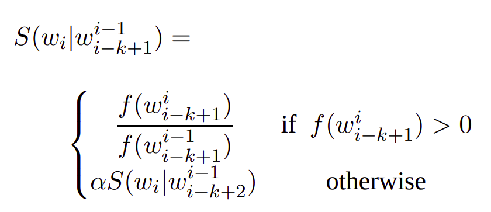

## Testing the accuracy and perfomrance

To test the accuracy of my prediction model, I wrote a custom function that was randomly sampling the portion of the corpus that was not used to make the model. Next, the sampled sentences were cut after a random word and passed to the prediction algorithm. Then, the 3 most likely words were compared with the correct one to calculate the accuracy of the algorithm.

In the testing phase I sampled a third of the provided corpus and I evaluated the accuracy of two major approaches: with and without stop-words.

The model where the stop-words were removed was performing very poorly - it had about 3% of correct prediction in the first 3 words. When stop-words were included the model oscillated at about 25% of correct prediction in the first 3 words.

Later, on I tried to increase the percentage of the corpus included in building the model. I managed to go up to 75% of the coverage of the corpus. Interestingly, the improvement of the accuracy of the prediction was limited to few percent with huge loss of speed.

For the final app that is presented here I used a third of the corpus with stop-words.

## Presentation of the App

For the finished app I decided to use a very simple interface with the reactive feature of the Shiny App.

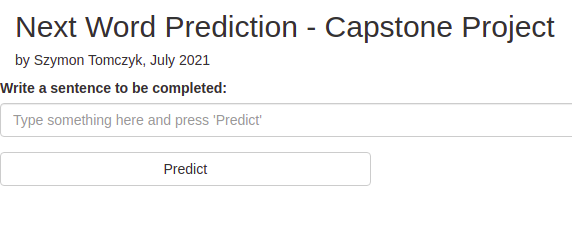

When the user types something in the text box and presses “Predict”. The algorithm will suggest 5 most likely words that could follow the input phrase.